# Network Analytics in R

jy

2021-09-26

## Intro

Notes from DataCamp course [‘Network Analysis in R’](https://learn.datacamp.com/courses/network-analysis-in-r).

Focus on social networks.

### Key Concepts 01

- Vertices: aka nodes, in this case, people in the social network.
- Edges: links between the vertices.
- Adjacency matrix: matrix with vertices as rows and columns, with values at the intersections representing edges
  - at minimum, 0 = no edge, 1 = edge exists between the vertices; can be higher values to represent attributes.
- Edgelist: list of combinations of vertices with edge values.

### Get Data

```r
## get list of datasets in igraphdata
data(package='igraphdata')
## import data set
data('UKfaculty', package='igraphdata')

## get description of UKfaculty
UKfaculty
```

```
## IGRAPH 6f42903 D-W- 81 817 --
## + attr: Type (g/c), Date (g/c), Citation (g/c), Author (g/c), Group
## | (v/n), weight (e/n)
## + edges from 6f42903:
##  [1] 57->52 76->42 12->69 43->34 28->47 58->51  7->29 40->71  5->37 48->55
## [11]  6->58 21-> 8 28->69 43->21 67->58 65->42  5->67 52->75 37->64  4->36
## [21] 12->49 19->46 37-> 9 74->36 62-> 1 15-> 2 72->49 46->62  2->29 40->12
## [31] 22->29 71->69  4-> 3 37->69  5-> 6 77->13 23->49 52->35 20->14 62->70
## [41] 34->35 76->72  7->42 37->42 51->80 38->45 62->64 36->53 62->77 17->61
## [51]  7->68 46->29 44->53 18->58 12->16 72->42 52->32 58->21 38->17 15->51
## [61] 22-> 7 22->69  5->13 29-> 2 77->12 37->35 18->46 10->71 22->47 20->19
## + ... omitted several edges
```

From this we can tell:

- Directed graph
- not Named graph: no ‘name’ attribute for vertices
- Weighted graph
- not Bipartite (don’t know what this is, not sure it comes up often)
- 81 vertices
- 817 edges
- attributes:
  - graph: Type (character), Date (character), Citation (character), Author (character),
  - vertices: Group (number)
  - edges: weight (edges/number)
- view of some edges

[Some explanation in official documentation here](https://igraph.org/r/doc/aaa-igraph-package.html)

#### Plot

Basic plot - we’ll do better later. ;)

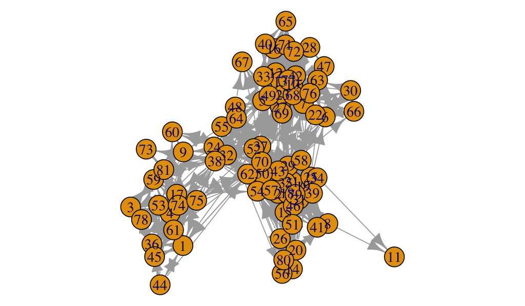

```r
## VERY useful for setting size - need to re-run for every code block with charts
par(mar=c(0,0,0,0))

## basic plot
plot(UKfaculty)
```

#### Additional Info

```r
## list of vertices
V(UKfaculty)
```

```
## + 81/81 vertices, from 6f42903:
##  [1]  1  2  3  4  5  6  7  8  9 10 11 12 13 14 15 16 17 18 19 20 21 22 23 24 25
## [26] 26 27 28 29 30 31 32 33 34 35 36 37 38 39 40 41 42 43 44 45 46 47 48 49 50
## [51] 51 52 53 54 55 56 57 58 59 60 61 62 63 64 65 66 67 68 69 70 71 72 73 74 75
## [76] 76 77 78 79 80 81
```

```r
## list of edges
E(UKfaculty)
```

```
## + 817/817 edges from 6f42903:
##   [1] 57->52 76->42 12->69 43->34 28->47 58->51  7->29 40->71  5->37 48->55
##  [11]  6->58 21-> 8 28->69 43->21 67->58 65->42  5->67 52->75 37->64  4->36
##  [21] 12->49 19->46 37-> 9 74->36 62-> 1 15-> 2 72->49 46->62  2->29 40->12
##  [31] 22->29 71->69  4-> 3 37->69  5-> 6 77->13 23->49 52->35 20->14 62->70
##  [41] 34->35 76->72  7->42 37->42 51->80 38->45 62->64 36->53 62->77 17->61
##  [51]  7->68 46->29 44->53 18->58 12->16 72->42 52->32 58->21 38->17 15->51
##  [61] 22-> 7 22->69  5->13 29-> 2 77->12 37->35 18->46 10->71 22->47 20->19
##  [71] 19->31 68->13 49->69 30->63  5->49 53->75 62->57 73->81 29->69 71->40
##  [81] 19->58 49->42 37-> 5 18-> 2 20->80 75->53 15->54 76->58 40->23  5->12
##  [91] 20->54  6->47 51->14 78-> 4 52->49 29->55 27->35 66-> 6 21->29  4->61
## + ... omitted several edges
```

```r
## number of edges
gsize(UKfaculty)
```

```
## [1] 817
```

```r
## number of vertices
gorder(UKfaculty)
```

```
## [1] 81
```

#### Attributes

Can also get attributes of the network graph itself, vertices and edges:

```r
graph_attr(UKfaculty)
```

```
## $Type
## [1] "TSPE"
##
## $Date
## [1] "Mon Mar 19 21:56:02 2007"
##
## $Citation
## [1] "Nepusz T., Petroczi A., Negyessy L., Bazso F.: Fuzzy communities and the concept of bridgeness in complex networks. Physical Review E, 77:016107, 2008."
##
## $Author
## [1] "Nepusz T., Petroczi A., Negyessy L., Bazso F."
```

```r
vertex_attr(UKfaculty)
```

```
## $Group
##  [1] 3 1 3 3 2 2 2 1 3 2 1 2 2 1 1 2 3 1 1 1 1 2 2 1 1 1 2 2 1 2 1 1 2 1 1 3 1 3
## [39] 1 2 1 2 1 3 3 1 2 1 2 4 1 1 3 1 1 1 1 1 3 3 3 3 2 1 2 2 2 2 2 4 2 2 3 3 3 2
## [77] 2 3 1 1 3
```

```r
edge_attr(UKfaculty)
```

```
## $weight
##   [1]  4 14  4  4 10  2  6  2  4  4  1  3  1  2  2  2  8  1  2  1 10  6  3  8  2
##  [26]  4  1  4  2  1  4  2  1  3  1  4 14  2 10 10  1  2  2  3  8  1  2  4  1  3
##  [51]  2  4  1 14  2  8  4  1  1  1  1  2 10 12  6  2 14  4  2  2  8  4  6  1  3
##  [76]  2  1 10 12  4  2  6  2 16 14  8  5  8  1  1  1  1  6 10  6  1  1  6 12  4
## [101]  2 12  2  8  1  1  2 12  8  2 10  1  6  1  2  4 12  2  4 14 16  1  2  2 14
## [126]  1  1  4 10  1  1 14  3  6  4 10  8  3  8  1  2  2  2  6  3  4 14  8  4  2
## [151]  1 12  1 10 14  6 12  6  2 16  6  4 12  2  2 12  1 14 12 10  6  1  6 16  3
## [176]  6  2  1  1  4 14  1  6  2  2  7 10  1  2  1  3  1  4  1  8  2  6  6  2  8
## [201]  1  2  1  1  4  6  4  6  2 10  2  2  4 14  4  2  2  2 16  2  2  1  2  2 10
## [226]  2  1  1 14  1 16  1  4  1  4  2  1  6  1  2  8  2  1  1  8  2  1  5  2  4
## [251]  4  2 10 12 14  2  2  2  2  2  1  6  1  1  6  2 10  4  1 12  2  2 14  2  1
## [276]  3  1 14  2  4  1  1 16  2  1  2 16  2  6  2  1  1  2  1  8  4  1  2 10  6
## [301]  4  2  4  1  2  3  1  8  2 14  2  8  2  1  6  1  1  8  1  1  1  2  8  4  2
## [326]  2  2  1  3  1  1  1 16 12  4 14  2  1  4  3 12 16  6  8 10 14  6  1  1  4
```

[output cut: 19 more lines]

### Add Attributes

- Note graph name change for convenience and to save original

Vertex attributes

```r
## using baby names data retrieved from https://www.ssa.gov/oact/babynames/limits.html, just for fun
## saved as: 'data/baby-names-1880'
new_attributes <- read_csv('data/baby-names-1880')
## get list same length as number of vertices
new_att <- sample_n(new_attributes, size=gorder(UKfaculty))

## change name for backup
ukf <- UKfaculty

ukf <- set_vertex_attr(ukf, name='leader', value=new_att$name)
ukf <- set_vertex_attr(ukf, name='type', value=new_att$gender)
ukf <- set_vertex_attr(ukf, name='size', value=new_att$count)

## check vertex attributes
vertex_attr(ukf)
```

```
## $Group
##  [1] 3 1 3 3 2 2 2 1 3 2 1 2 2 1 1 2 3 1 1 1 1 2 2 1 1 1 2 2 1 2 1 1 2 1 1 3 1 3
## [39] 1 2 1 2 1 3 3 1 2 1 2 4 1 1 3 1 1 1 1 1 3 3 3 3 2 1 2 2 2 2 2 4 2 2 3 3 3 2
## [77] 2 3 1 1 3
##
## $leader
##  [1] "Clarke"    "Bennie"    "Emmitt"    "Ted"       "Otis"      "Gordon"
##  [7] "Franklin"  "Marion"    "Corinne"   "Bama"      "Augustine" "Maryann"
## [13] "Avis"      "Francisco" "Lonnie"    "Hannah"    "Tessie"    "Loren"
## [19] "Gena"      "Edson"     "Alyce"     "Tabitha"   "Nealie"    "Ferd"
## [25] "Benton"    "Cyrus"     "Roderick"  "Rex"       "Carl"      "Judy"
## [31] "Hanna"     "Lular"     "Dolphus"   "Reta"      "Delos"     "Herman"
## [37] "Hershel"   "Cliff"     "Gustavus"  "Lona"      "Lincoln"   "Spurgeon"
## [43] "Addie"     "Mat"       "Maymie"    "Mettie"    "Madeline"  "Shirley"
## [49] "Genie"     "Hunt"      "Artie"     "Wm"        "Edd"       "James"
```

[output cut: 19 more lines]

```r
## view the vertices
V(ukf)[[1:5]]
```

```
## + 5/81 vertices, from 6f42903:
##   Group leader type size
## 1     3 Clarke    M    6
## 2     1 Bennie    M   26
## 3     3 Emmitt    M    7
## 4     3    Ted    M   13
## 5     2   Otis    M   88
```

Sweet! More attributes to understand characteristics of the network.

Edge Attributes: set and view

```r
## add an attribute to edges to indicate strength
strength <- sample(x=seq(1:20), size=gsize(ukf), replace=TRUE)

ukf <- set_edge_attr(ukf, name='strength', value=strength)

edge_attr(ukf)
```

```
## $weight
##   [1]  4 14  4  4 10  2  6  2  4  4  1  3  1  2  2  2  8  1  2  1 10  6  3  8  2
##  [26]  4  1  4  2  1  4  2  1  3  1  4 14  2 10 10  1  2  2  3  8  1  2  4  1  3
##  [51]  2  4  1 14  2  8  4  1  1  1  1  2 10 12  6  2 14  4  2  2  8  4  6  1  3
##  [76]  2  1 10 12  4  2  6  2 16 14  8  5  8  1  1  1  1  6 10  6  1  1  6 12  4
## [101]  2 12  2  8  1  1  2 12  8  2 10  1  6  1  2  4 12  2  4 14 16  1  2  2 14
## [126]  1  1  4 10  1  1 14  3  6  4 10  8  3  8  1  2  2  2  6  3  4 14  8  4  2
## [151]  1 12  1 10 14  6 12  6  2 16  6  4 12  2  2 12  1 14 12 10  6  1  6 16  3
## [176]  6  2  1  1  4 14  1  6  2  2  7 10  1  2  1  3  1  4  1  8  2  6  6  2  8
## [201]  1  2  1  1  4  6  4  6  2 10  2  2  4 14  4  2  2  2 16  2  2  1  2  2 10
## [226]  2  1  1 14  1 16  1  4  1  4  2  1  6  1  2  8  2  1  1  8  2  1  5  2  4
## [251]  4  2 10 12 14  2  2  2  2  2  1  6  1  1  6  2 10  4  1 12  2  2 14  2  1
## [276]  3  1 14  2  4  1  1 16  2  1  2 16  2  6  2  1  1  2  1  8  4  1  2 10  6
## [301]  4  2  4  1  2  3  1  8  2 14  2  8  2  1  6  1  1  8  1  1  1  2  8  4  2
## [326]  2  2  1  3  1  1  1 16 12  4 14  2  1  4  3 12 16  6  8 10 14  6  1  1  4
```

[output cut: 54 more lines]

### Subset Edges

```r
## view first 5 in edge list
E(ukf)[[1:5]]
```

```
## + 5/817 edges from 6f42903:
##   tail head tid hid weight strength
## 1   57   52  57  52      4        4
## 2   76   42  76  42     14       10
## 3   12   69  12  69      4       15
## 4   43   34  43  34      4       17
## 5   28   47  28  47     10       10
```

```r
## select edges that include '12' in either 'tail' or 'head'
E(ukf)[[inc(12)]]
```

```
## + 19/817 edges from 6f42903:
##     tail head tid hid weight strength
## 3     12   69  12  69      4       15
## 21    12   49  12  49     10        5
## 30    40   12  40  12      1       18
## 55    12   16  12  16      2       10
## 65    77   12  77  12      6       10
## 90     5   12   5  12      1       16
## 115   12   23  12  23      2        9
## 139   23   12  23  12      8        6
## 240   12   22  12  22      2        4
## 282    7   12   7  12      1       12
## 286   68   12  68  12      2        9
## 293   22   12  22  12      2       14
## 324   12   77  12  77      4       11
## 326   69   12  69  12      2       17
## 438   16   12  16  12      6       10
## 479   43   12  43  12      3       13
## 646   13   12  13  12      6       15
## 649   49   12  49  12     12        1
## 701   33   12  33  12      2        4
```

```r
## select edges where strength =17
E(ukf)[[strength==17]]
```

```
## + 45/817 edges from 6f42903:
##     tail head tid hid weight strength
## 4     43   34  43  34      4       17
## 11     6   58   6  58      1       17
## 89    40   23  40  23      1       17
## 100    4   61   4  61      4       17
## 104    5   64   5  64      8       17
## 113   43   54  43  54      6       17
## 159   17    3  17   3      2       17
## 165    5   76   5  76      2       17
## 175   37   32  37  32      3       17
## 239   38    1  38   1      1       17
## 260   34   46  34  46      2       17
## 267    7   77   7  77     10       17
## 273   26   20  26  20     14       17
```

[output cut: 32 more lines]

## Alternate dataset

Can investigate this one in parallel - might be closer case to the course, as well as practical relevance.

### Creating graph from data frames

```r
t_nodes <- data.frame(names=c('BL','CL','EB','JA','JY','IK','KK','MM','SN','TF','VN'),
                    role=c('Sr Analyst','Adv Analyst', 'Jr Analyst','Analyst','Sr Manager','Analyst','Engineer','Manager','Sr Analyst','Sr Analyst','Sr Analyst'))

t_edges <- tribble(
  ~from, ~to, ~weight,
  "BL", "JY", 4,
  "CL", "JY", 3,
  "EB", "MM", 2,
  "JA", "JY", 1,
  "IK", "MM", 1,
  "KK", "JY", 1,
  "MM", "JY", 1,
  "SN", "MM", 3,
  "TF", "JY", 1,
  "VN", "JY", 2)


t <- graph_from_data_frame(d=t_edges, directed=TRUE, vertices=t_nodes)

t
```

```
## IGRAPH 72bd8ef DNW- 11 10 --
## + attr: name (v/c), role (v/c), weight (e/n)
## + edges from 72bd8ef (vertex names):
##  [1] BL->JY CL->JY EB->MM JA->JY IK->MM KK->JY MM->JY SN->MM TF->JY VN->JY
```

```r
vertex_attr(t)
```

```
## $name
##  [1] "BL" "CL" "EB" "JA" "JY" "IK" "KK" "MM" "SN" "TF" "VN"
##
## $role
##  [1] "Sr Analyst"  "Adv Analyst" "Jr Analyst"  "Analyst"     "Sr Manager"
##  [6] "Analyst"     "Engineer"    "Manager"     "Sr Analyst"  "Sr Analyst"
## [11] "Sr Analyst"
```

```r
edge_attr(t)
```

```
## $weight
##  [1] 4 3 2 1 1 1 1 3 1 2
```

#### Plot

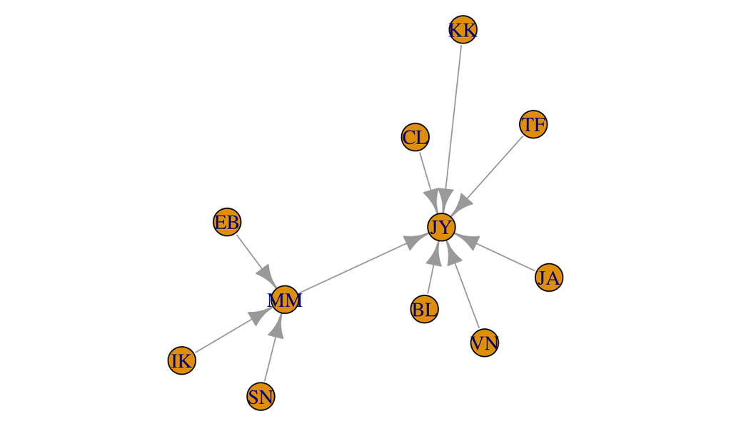

```r
## VERY useful for setting size - need to re-run for every code block with charts
par(mar=c(0,0,0,0))
plot(t)
```

```r
## add attribute to network vertices
t <- set_vertex_attr(t, name='gender', value=c('M','F','F','M','M','F','M','F','M','M','F'))
vertex_attr(t)
```

```
## $name
##  [1] "BL" "CL" "EB" "JA" "JY" "IK" "KK" "MM" "SN" "TF" "VN"
##
## $role
##  [1] "Sr Analyst"  "Adv Analyst" "Jr Analyst"  "Analyst"     "Sr Manager"
##  [6] "Analyst"     "Engineer"    "Manager"     "Sr Analyst"  "Sr Analyst"
## [11] "Sr Analyst"
##
## $gender
##  [1] "M" "F" "F" "M" "M" "F" "M" "F" "M" "M" "F"
```

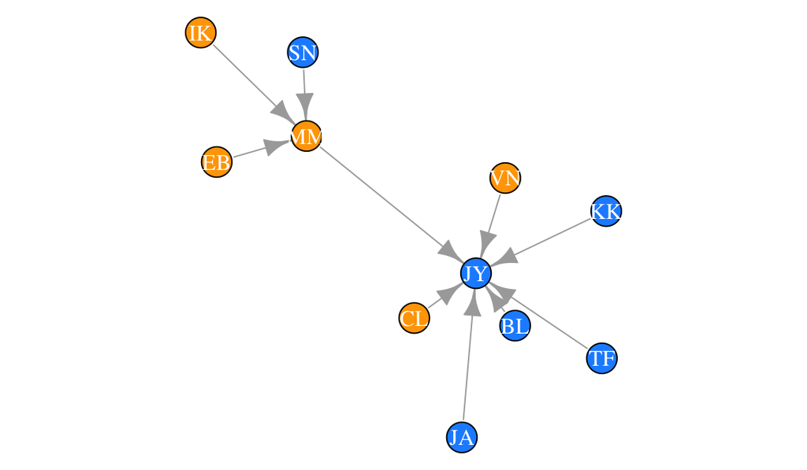

```r
## set par for better sizing
par(mar=c(0,0,0,0))

V(t)$color <- ifelse(V(t)$gender=='F','orange','dodgerblue')

plot(t, vertex.label.color="white")
```

- node color based on gender
- labels set to white

### Other Plot Options

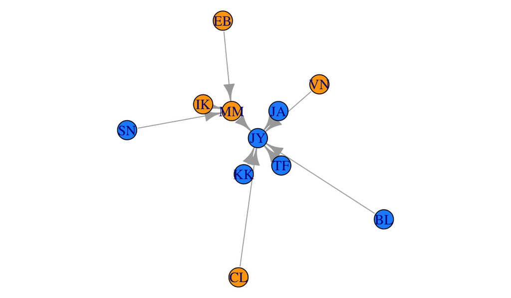

```r
## very useful in increasing default size! need to run with every code block that has plot
par(mar=c(0,0,0,0))

## recommended in other course
plot(t, layout=layout_with_kk(t))
```

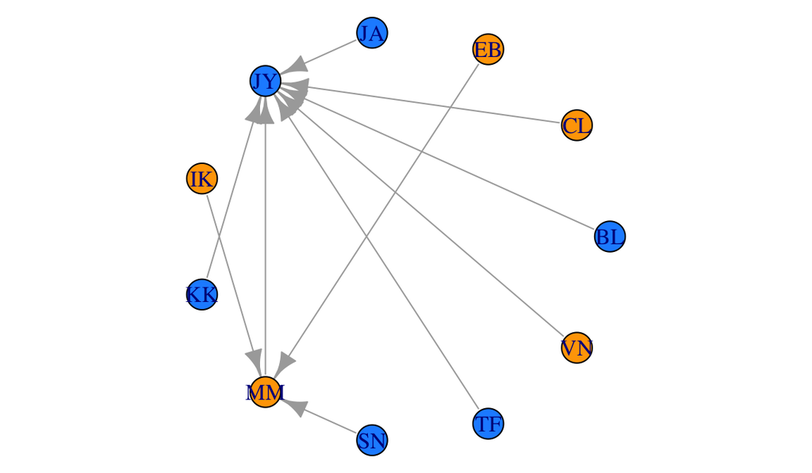

```r
## circle
plot(t, layout=layout_in_circle)
```

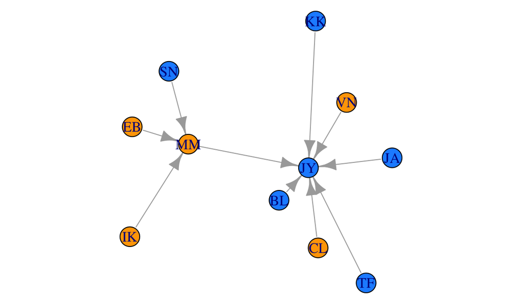

```r
## fruchterman-reingold
plot(t, layout=layout_with_fr)
```

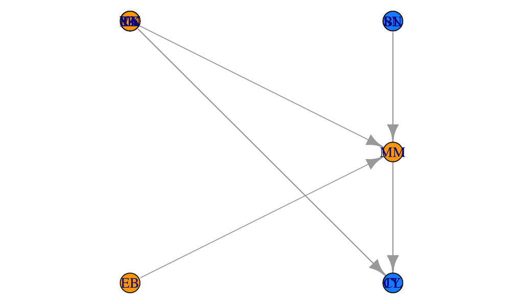

```r
## layout as tree (doesn't seem to work - could be due to graph structure)
plot(t, layout=layout_as_tree(t))
```

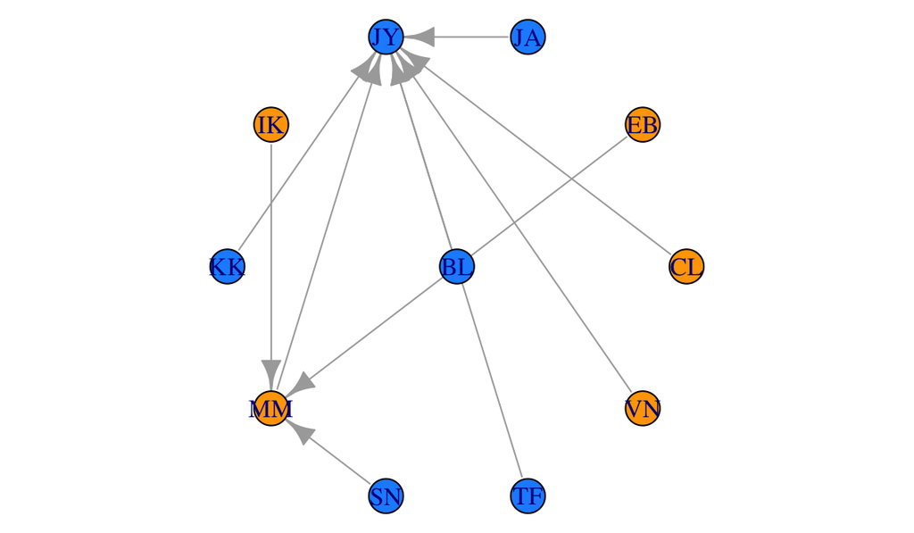

```r
## layout as star - looks like some inappropriate crossing (in some versions)
plot(t, layout=layout_as_star)
```

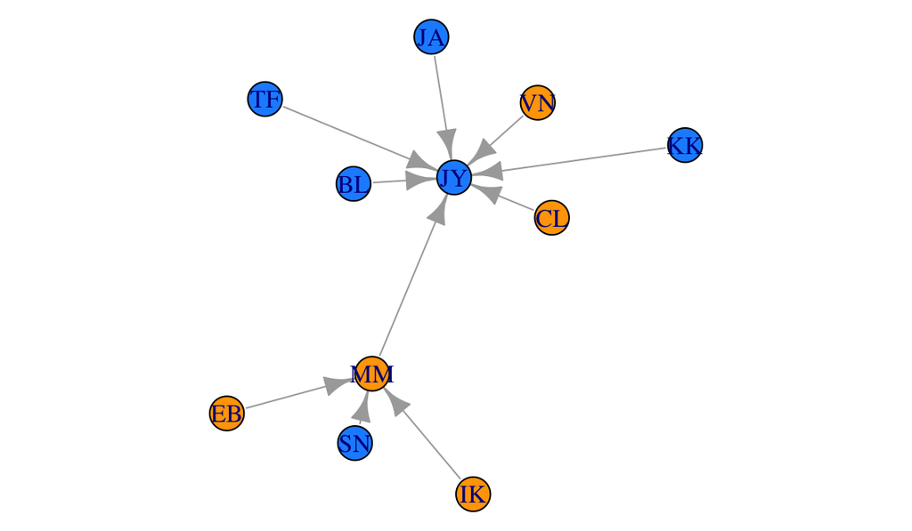

```r
## igraph's choice
m1 <- layout_nicely(t)
plot(t, layout=m1)
```

#### Parameters

[Info on igraph plot parameters](https://www.r-graph-gallery.com/248-igraph-plotting-parameters.html)

- Node shape & size
- Edge weight
- Layout algo

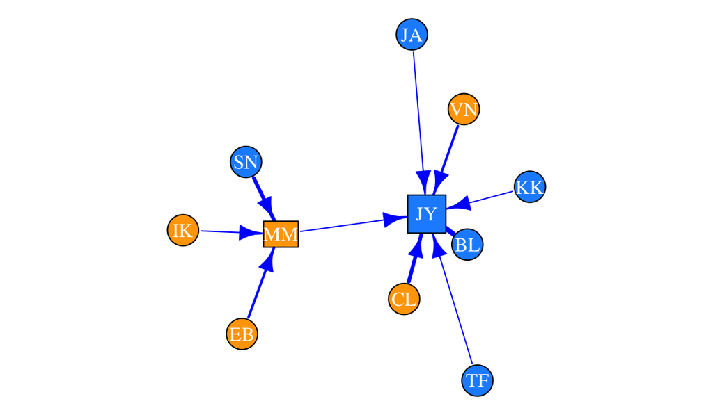

```r
## set par for better sizing
par(mar=c(0,0,0,0))

## NODE shape & size
## shape options are basically circle or square :( (there are variations but hard to tell what difference)
V(t)$shape <- ifelse(V(t)$role=='Sr Manager','square',
                     ifelse(V(t)$role=='Manager', 'rectangle','circle'))
## default size = 15; max appears to be 24
V(t)$size <- ifelse(V(t)$role=='Sr Manager',22,
                     ifelse(V(t)$role=='Manager', 20,18))

## EDGE weight
## set edge width
w1 <- E(t)$weight

## LAYOUT
## set layout -> really, default 'layout_nicely' seems to be the best option, usually
lay <- layout_with_fr(t)

plot(t, vertex.label.color="white",
     edge.width=w1,
     edge.color='blue',
     layout=lay)
```

Edge weights may need more relative separation:

```r
table(t_edges$weight)
```

```
##
## 1 2 3 4
## 5 2 2 1
```

## Plotting Original Dataset

Explore plotting techniques with larger data set.

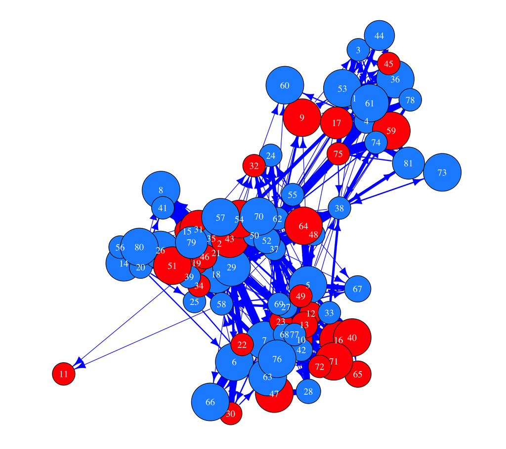

```r
par(mar=c(0,0,0,0))
#ukf
#vertex_attr(ukf)
#edge_attr(ukf)

## set node color
V(ukf)$color <- ifelse(V(ukf)$type=='F','red','dodgerblue')

## set size -> reduce variation to reasonable level
sizes <- V(ukf)$size
sizes <- ifelse(sizes>20, 20, ifelse(
  sizes<12,12, sizes
))

## plot with parameters
plot(ukf, edge.width=E(ukf)$weight,
     edge.color='blue',
     vertex.size=sizes,
     vertex.label.color='white',
     layout=layout_with_fr(ukf))
```

## Directional example

- check out another data set for consideration from igraphdata collection
- ideally looking for spread of contagious disease

```r
## possible alternative data set for exploration -> save for another time
## import data set
data('enron', package='igraphdata')
## check meta data
enron
```

```
## IGRAPH 64ec693 D--- 184 125409 -- Enron email network
## + attr: LDC_names (g/c), LDC_desc (g/c), name (g/c), Citation (g/c),
## | Email (v/c), Name (v/c), Note (v/c), Time (e/c), Reciptype (e/c),
## | Topic (e/n), LDC_topic (e/n)
## + edges from 64ec693:
##  [1]  25->154  25->154  30-> 30  30-> 30  30-> 30  30-> 30  39-> 39  52-> 67
##  [9]  52-> 67  52-> 67  52-> 67  61->100  61->100  61->163  61->163  61->166
## [17]  61->166  61->170  64-> 59  64-> 59  64-> 64  64-> 64  64->147  64->147
## [25]  64->164  64->164  64->168  66-> 66  66-> 66  67->129  67->129  67->129
## [33]  67->129  93-> 10  93-> 10  93-> 10  93-> 10  93-> 39  93-> 39  93-> 93
## [41]  93-> 93  93-> 93  93-> 93  93->124  93->124 100-> 61 100-> 61 115->115
## + ... omitted several edges
```

```r
## confirm count of nodes
gorder(enron)
```

```
## [1] 184
```

```r
## confirm count of edges
gsize(enron)
```

```
## [1] 125409
```

```r
## get random sample of nodes
V(enron)[[sample(x=seq(1:gorder(enron)), size=5, replace=FALSE)]]
```

```
## + 5/184 vertices, from 64ec693:
##             Email            Name                                     Note
## 77     joe.quenet      Joe Quenet                                   Trader
## 81  john.griffith              NA                                       NA
## 134     m..presto    Kevin Presto                           Vice President
## 20  cooper.richey   Cooper Richey                                  Manager
## 13     b..sanders Richard Sanders Vice President, Enron WholeSale Services
```

```r
## get sample of random selection of edges
E(enron)[[sample(x=seq(1:gsize(enron)), size=5, replace=FALSE)]]
```

```
## + 5/125409 edges from 64ec693:
##        tail head tid hid                Time Reciptype Topic LDC_topic
## 1282    156  111 156 111 1999-09-02 05:52:00       bcc     1        -1
## 93629    75  129  75 129 2001-09-12 13:39:08        to     1         0
## 97212    64  108  64 108 2001-10-02 18:53:16        to     1         0
## 113161   91  103  91 103 2001-11-23 16:27:01        to     1         0
## 76794     3  155   3 155 2001-05-02 13:07:00        to     1         0
```

- could be interesting for another time - can go with ‘t’ for now; can go with ukr, since it has direction.